# Interrupted Time Series ARIMA Analysis

# 1 Introduction

This document uses an interrupted time series ARIMA analysis to evaluate changes in mortality (assault and all-cause) following the June 2021 Bill 8 policy intervention restricting access to abortion in Texas.

Data are from the CDC Multiple Cause of Death Database, including monthly Texas resident death counts from 2018-Dec 2023. We fit both female and male, though note that we plan to just report female, including one male model as a counterfactual comparison.

# 2 Methods

R code is adapted from this [RPubs article on tidy structure for ITS ARIMAs](https://rpubs.com/jcorbin/tidy_itt_arima)

The ARIMA model incorporates:

- **Autoregressive terms (AR)** to capture dependence on previous observations
- **Integrated differencing (I)** to remove non-stationary trends
- **Moving average terms (MA)** to account for serial correlation in residual errors

The intervention is modeled using:

- **Step variable**: immediate level change after the intervention
- **Ramp variable**: gradual slope change after the intervention

Counterfactual forecasts are generated using the **pre-intervention ARIMA structure**, representing expected mortality trajectories if the policy had not occurred.

## 2.1 Analysis Structure

1. All-Cause

We will start by reviewing the ARIMA for **All-Cause Mortality**, so we may capture any changes in death trends overall, accounting for the fact that deaths by assault are often misrecorded by government agencies.

2. Reproductive-aged Assault Mortality

We will then explore deaths by assault among women aged 15-44.

3. All-age Assault Mortality

Lastly, we will investigate assault mortality among all ages, not just reproductive.

# 3 All-Cause Mortality

## 3.1 Results

### 3.1.1 Male

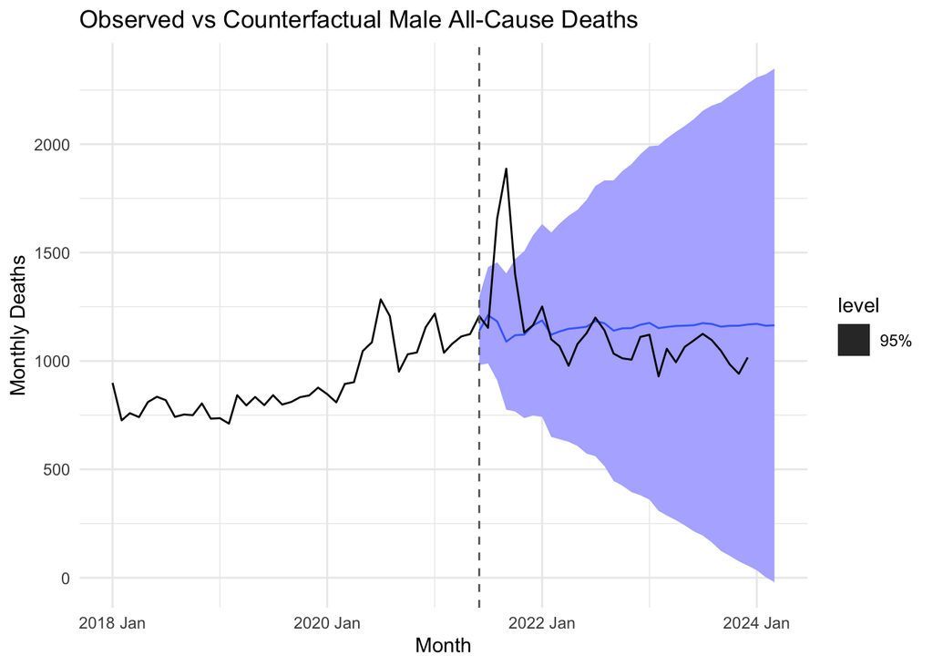

```r
monthly_m.ts <- prepare_ts("../CleanData/all_cause_repro_m.csv")
monthly_m.ts <- create_intervention(monthly_m.ts, "2021-06-01")

m_arima <- fit_arima(monthly_m.ts)

fc_m <- counterfactual_forecast(monthly_m.ts, "2021-06-01", 34)

plot_counterfactual(
  fc_m,
  monthly_m.ts,
  "2021-06-01",
  "Observed vs Counterfactual Male All-Cause Deaths"
)
```

### 3.1.2 Female

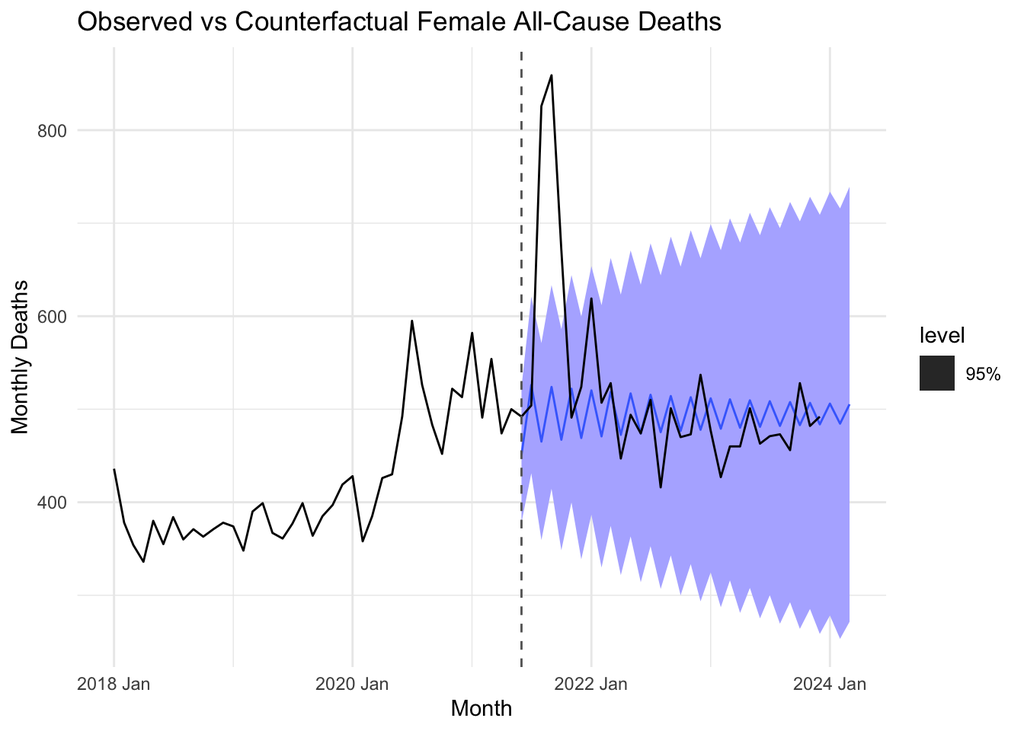

```r
monthly_f.ts <- prepare_ts("../CleanData/all_cause_repro_f.csv")
monthly_f.ts <- create_intervention(monthly_f.ts, "2021-06-01")

f_arima <- fit_arima(monthly_f.ts)

fc_f <- counterfactual_forecast(monthly_f.ts, "2021-06-01", 34)

plot_counterfactual(
  fc_f,
  monthly_f.ts,
  "2021-06-01",
  "Observed vs Counterfactual Female All-Cause Deaths"
)
```

## 3.2 Model Estimates

The **step coefficient** represents the immediate change in deaths following the intervention, while the **ramp coefficient** estimates the monthly change in slope after the intervention.

```r
report(m_arima)
```

```
## Series: Deaths
## Model: LM w/ ARIMA(4,0,0) errors
##
## Coefficients:
##          ar1      ar2     ar3     ar4      step      ramp  intercept
##       0.8266  -0.4011  0.1343  0.2315  377.0418  -10.1464   905.9817
## s.e.  0.1171   0.1521  0.1510  0.1159   91.8799    5.3946    65.5346
##
## sigma^2 estimated as 11478:  log likelihood=-435.67
## AIC=887.33   AICc=889.62   BIC=905.54
```

```r
report(f_arima)
```

```
## Series: Deaths
## Model: LM w/ ARIMA(4,0,0) errors
##
## Coefficients:
##          ar1      ar2      ar3     ar4     step     ramp  intercept
##       0.6380  -0.1338  -0.1073  0.3361  140.306  -3.4020   424.9892
## s.e.  0.1136   0.1326   0.1333  0.1104   49.707   2.6703    29.4805
##
## sigma^2 estimated as 3578:  log likelihood=-393.54
## AIC=803.09   AICc=805.38   BIC=821.3
```

## 3.3 Model Diagnostics

**Residual Diagnostics**

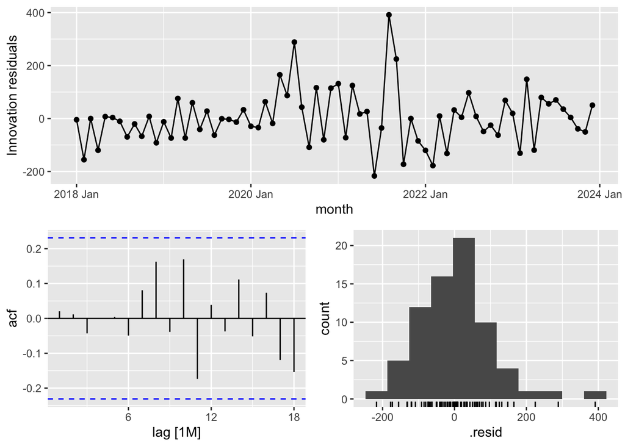

```r
m_arima %>% gg_tsresiduals()
```

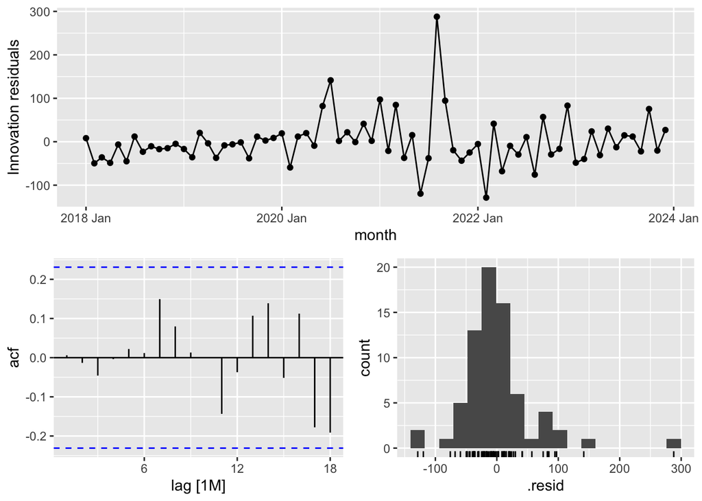

```r
f_arima %>% gg_tsresiduals()
```

**Ljung-Box Test**

```r
augment(m_arima) %>% features(.resid, ljung_box)
```

```
## # A tibble: 1 × 3
##   .model lb_stat lb_pvalue
##   <chr>    <dbl>     <dbl>
## 1 arima   0.0314     0.859
```

```r
augment(f_arima) %>% features(.resid, ljung_box)
```

```
## # A tibble: 1 × 3
##   .model lb_stat lb_pvalue
##   <chr>    <dbl>     <dbl>
## 1 arima  0.00276     0.958
```

## 3.4 Sensitivity Analysis

**Pre-Intervention Model Selection - Female and Male**

```r
pre_data_f <- monthly_f.ts %>%
  filter(month_year < "2021-06-01")

pre_data_m <- monthly_m.ts %>%
  filter(month_year < "2021-06-01")

f_pre <- pre_data_f %>%
  model(arima = ARIMA(Deaths))

m_pre <- pre_data_m %>%
  model(arima = ARIMA(Deaths))

report(f_pre)
```

```
## Series: Deaths
## Model: ARIMA(0,1,1)
##
## Coefficients:
##           ma1
##       -0.4369
## s.e.   0.1943
##
## sigma^2 estimated as 1660:  log likelihood=-204.65
## AIC=413.31   AICc=413.63   BIC=416.69
```

```r
report(m_pre)
```

```
## Series: Deaths
## Model: ARIMA(0,1,0)(1,0,0)[12]
##
## Coefficients:
##         sar1
##       0.3645
## s.e.  0.1951
##
## sigma^2 estimated as 6432:  log likelihood=-232.49
## AIC=468.97   AICc=469.3   BIC=472.35
```

**Fitting with Full Data**

```r
f_sensitivity <- monthly_f.ts %>%
  model(
    arima = ARIMA(
      Deaths ~ step + ramp + pdq(0,0,1),
      stepwise = FALSE
    )
  )

m_sensitivity <- monthly_m.ts %>%
  model(
    arima = ARIMA(
      Deaths ~ step + ramp + pdq(0,1,0) + PDQ(1,0,0),
      stepwise = FALSE
    )
  )

report(f_sensitivity)
```

```
## Series: Deaths
## Model: LM w/ ARIMA(0,0,1) errors
##
## Coefficients:
##          ma1      step     ramp  intercept
##       0.5095  165.2439  -4.6606   423.8770
## s.e.  0.0795   36.7400   1.8561    14.8913
##
## sigma^2 estimated as 4315:  log likelihood=-401.57
## AIC=813.13   AICc=814.04   BIC=824.52
```

```r
report(m_sensitivity)
```

```
## Series: Deaths
## Model: LM w/ ARIMA(0,1,0)(1,0,0)[12] errors
##
## Coefficients:
##          sar1      step     ramp
##       -0.0427   93.3978  -6.2937
## s.e.   0.1163  124.6842  21.7552
##
## sigma^2 estimated as 15598:  log likelihood=-441.97
## AIC=891.94   AICc=892.55   BIC=901
```

**Forecasted Graphs**

[figure not shown]

```r
fc_counterfactual_f <- f_pre %>%
  forecast(h = 28+4)

fc_counterfactual_m <- m_pre %>%
  forecast(h = 28+4)

autoplot(fc_counterfactual_f, monthly_f.ts, level = 95) +
  geom_vline(
    xintercept = as.numeric(as_date("2021-06-01")),
    linetype = "dashed",
    color = "grey40"
  ) +
  labs(
    title = "Observed vs Counterfactual Female Assault Deaths",
    y = "Monthly Deaths",
    x = "Month"
  ) +
  scale_y_continuous(expand = c(0,0)) +
  theme_minimal()
```

[figure not shown]

```r
autoplot(fc_counterfactual_m, monthly_m.ts, level = 95) +
  geom_vline(
    xintercept = as.numeric(as_date("2021-06-01")),
    linetype = "dashed",
    color = "grey40"
  ) +
  labs(
    title = "Observed vs Counterfactual Male Assault Deaths",
    y = "Monthly Deaths",
    x = "Month"
  ) +
  scale_y_continuous(expand = c(0,0)) +
  theme_minimal()
```

# 4 Assault Mortality

## 4.1 Results

### 4.1.1 Male

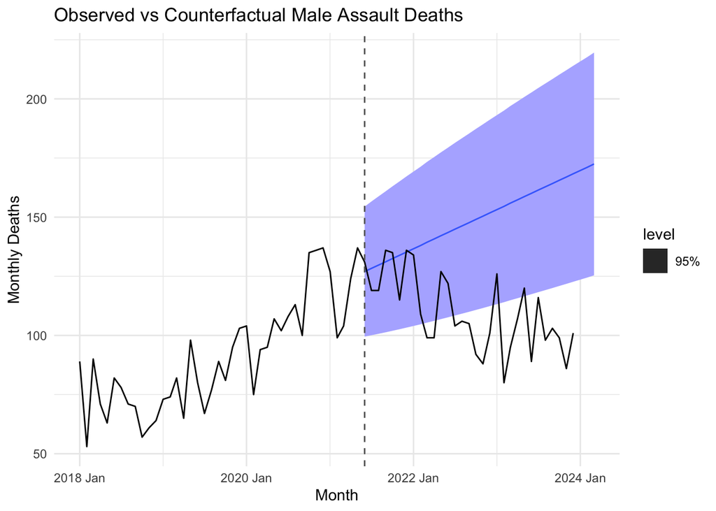

```r
monthly_m.ts <- prepare_ts("../CleanData/monthly_m.csv")
monthly_m.ts <- create_intervention(monthly_m.ts, "2021-06-01")

m_arima <- fit_arima(monthly_m.ts)

fc_m <- counterfactual_forecast(monthly_m.ts, "2021-06-01", 34)

plot_counterfactual(
  fc_m,
  monthly_m.ts,
  "2021-06-01",
  "Observed vs Counterfactual Male Assault Deaths"
)
```

### 4.1.2 Female

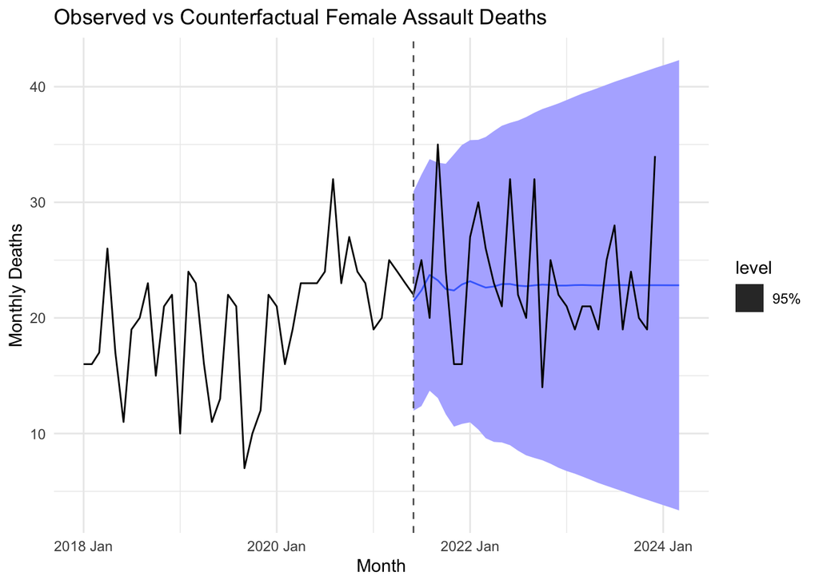

```r
monthly_f.ts <- prepare_ts("../CleanData/monthly_f.csv")
monthly_f.ts <- create_intervention(monthly_f.ts, "2021-06-01")

f_arima <- fit_arima(monthly_f.ts)

fc_f <- counterfactual_forecast(monthly_f.ts, "2021-06-01", 34)

plot_counterfactual(
  fc_f,
  monthly_f.ts,
  "2021-06-01",
  "Observed vs Counterfactual Female Assault Deaths"
)
```

## 4.2 Model Estimates

```r
report(m_arima)
```

```
## Series: Deaths
## Model: LM w/ ARIMA(0,1,1)(1,0,0)[12] errors
##
## Coefficients:
##           ma1    sar1    step     ramp  intercept
##       -0.8051  0.2867  1.9327  -2.5354     1.4407
## s.e.   0.0898  0.1307  7.8154   0.7998     0.5525
##
## sigma^2 estimated as 179.3:  log likelihood=-283.39
## AIC=578.77   AICc=580.09   BIC=592.35
```

```r
report(f_arima)
```

```
## Series: Deaths
## Model: LM w/ ARIMA(0,0,5) errors
##
## Coefficients:
##           ma1      ma2     ma3     ma4     ma5    step     ramp  intercept
##       -0.0005  -0.1056  0.1257  0.2347  0.3621  5.1949  -0.0727    19.4511
## s.e.   0.1134   0.1174  0.1035  0.1113  0.1182  2.3892   0.1241     1.1175
##
## sigma^2 estimated as 24.48:  log likelihood=-213.66
## AIC=445.31   AICc=448.22   BIC=465.8
```

## 4.3 Model Diagnostics

**Residual Diagnostics**

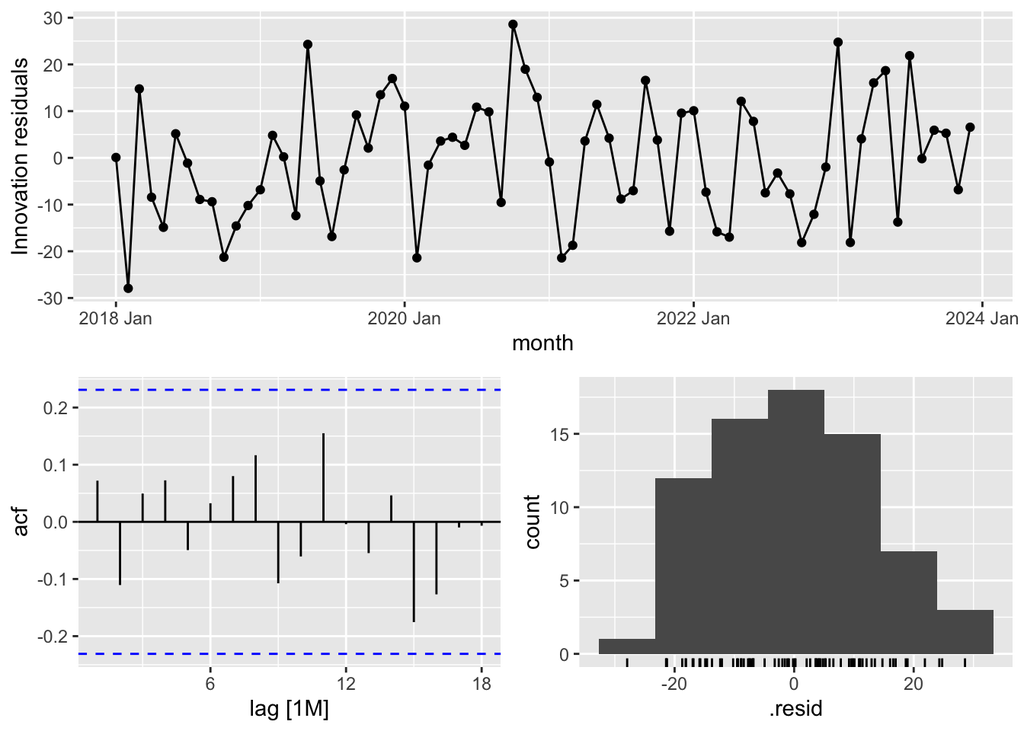

```r
m_arima %>% gg_tsresiduals()
```

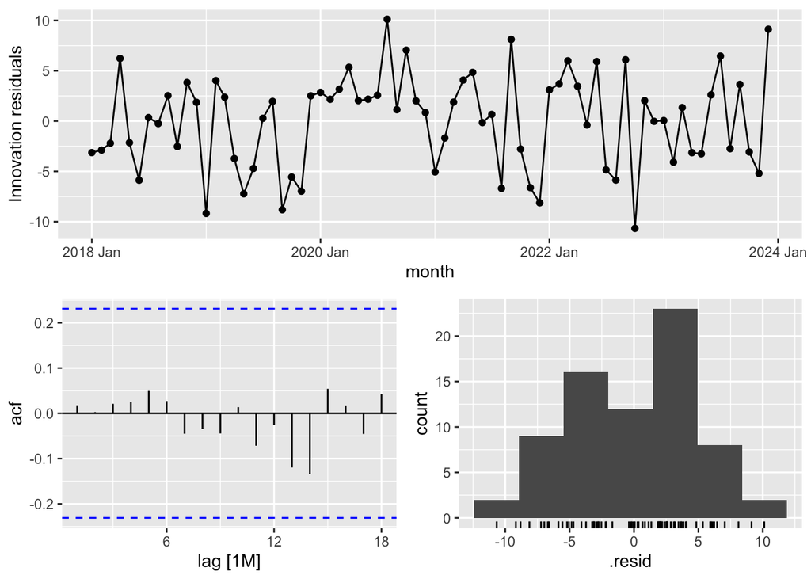

```r
f_arima %>% gg_tsresiduals()
```

**Ljung-Box Test**

```r
augment(m_arima) %>% features(.resid, ljung_box)
```

```
## # A tibble: 1 × 3
##   .model lb_stat lb_pvalue
##   <chr>    <dbl>     <dbl>
## 1 arima    0.389     0.533
```

```r
augment(f_arima) %>% features(.resid, ljung_box)
```

```
## # A tibble: 1 × 3
##   .model lb_stat lb_pvalue
##   <chr>    <dbl>     <dbl>
## 1 arima   0.0237     0.878
```

## 4.4 Sensitivity Analysis

**Pre-Intervention Model Selection - Female and Male**

```r
pre_data_f <- monthly_f.ts %>%
  filter(month_year < "2021-06-01")

pre_data_m <- monthly_m.ts %>%
  filter(month_year < "2021-06-01")

f_pre <- pre_data_f %>%
  model(arima = ARIMA(Deaths))

m_pre <- pre_data_m %>%
  model(arima = ARIMA(Deaths))

report(f_pre)
```

```
## Series: Deaths
## Model: ARIMA(0,1,1)
##
## Coefficients:
##           ma1
##       -0.7497
## s.e.   0.1178
##
## sigma^2 estimated as 26.44:  log likelihood=-122.16
## AIC=248.32   AICc=248.65   BIC=251.7
```

```r
report(m_pre)
```

```
## Series: Deaths
## Model: ARIMA(0,1,1) w/ drift
##
## Coefficients:
##           ma1  constant
##       -0.7579    1.3786
## s.e.   0.1281    0.5786
##
## sigma^2 estimated as 196.6:  log likelihood=-161.78
## AIC=329.57   AICc=330.23   BIC=334.63
```

**Fitting with Full Data**

```r
f_sensitivity <- monthly_f.ts %>%
  model(
    arima = ARIMA(
      Deaths ~ step + ramp + pdq(0,0,1),
      stepwise = FALSE
    )
  )

m_sensitivity <- monthly_m.ts %>%
  model(
    arima = ARIMA(
      Deaths ~ step + ramp + pdq(0,1,0) + PDQ(1,0,0),
      stepwise = FALSE
    )
  )

report(f_sensitivity)
```

```
## Series: Deaths
## Model: LM w/ ARIMA(0,0,1) errors
##
## Coefficients:
##          ma1    step     ramp  intercept
##       0.1621  4.0638  -0.0212    19.5959
## s.e.  0.1329  2.3854   0.1202     0.9373
##
## sigma^2 estimated as 28.44:  log likelihood=-220.64
## AIC=451.28   AICc=452.19   BIC=462.67
```

```r
report(m_sensitivity)
```

```
## Series: Deaths
## Model: LM w/ ARIMA(0,1,0)(1,0,0)[12] errors
##
## Coefficients:
##         sar1     step     ramp
##       0.2860  -2.4107  -1.2853
## s.e.  0.1358  15.7324   3.5109
##
## sigma^2 estimated as 270.8:  log likelihood=-298.57
## AIC=605.14   AICc=605.74   BIC=614.19
```

**Forecasted Graphs**

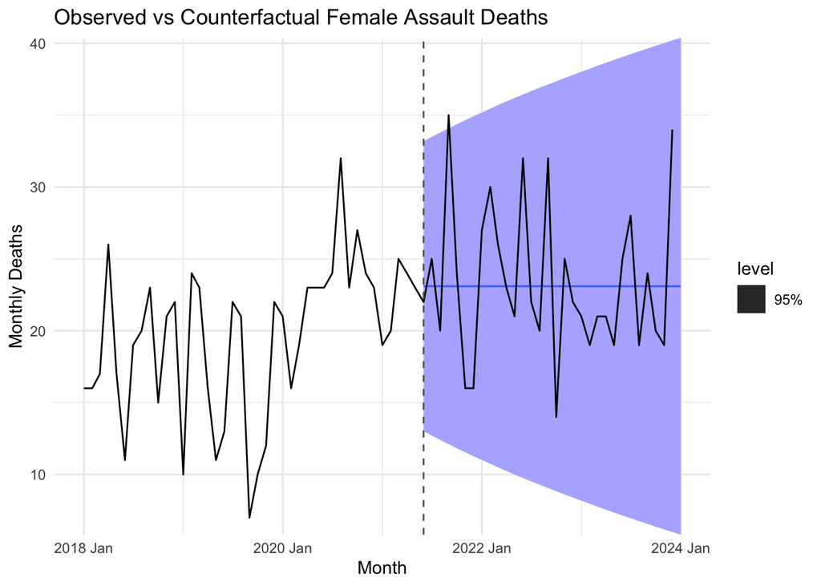

```r
fc_counterfactual_f <- f_pre %>%
  forecast(h = 28+4)

fc_counterfactual_m <- m_pre %>%
  forecast(h = 28+4)

autoplot(fc_counterfactual_f, monthly_f.ts, level = 95) +
  geom_vline(
    xintercept = as.numeric(as_date("2021-06-01")),
    linetype = "dashed",
    color = "grey40"
  ) +
  labs(
    title = "Observed vs Counterfactual Female Assault Deaths",
    y = "Monthly Deaths",
    x = "Month"
  ) +
  scale_y_continuous(expand = c(0,0)) +
  theme_minimal()
```

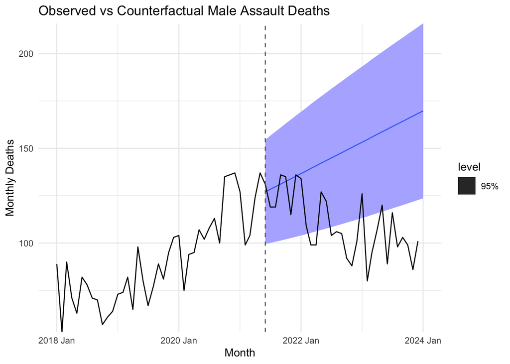

```r
autoplot(fc_counterfactual_m, monthly_m.ts, level = 95) +
  geom_vline(
    xintercept = as.numeric(as_date("2021-06-01")),
    linetype = "dashed",
    color = "grey40"
  ) +
  labs(
    title = "Observed vs Counterfactual Male Assault Deaths",
    y = "Monthly Deaths",
    x = "Month"
  ) +
  scale_y_continuous(expand = c(0,0)) +
  theme_minimal()
```

## 4.5 All-Age Assault Mortality

## 4.6 Results

### 4.6.1 Male

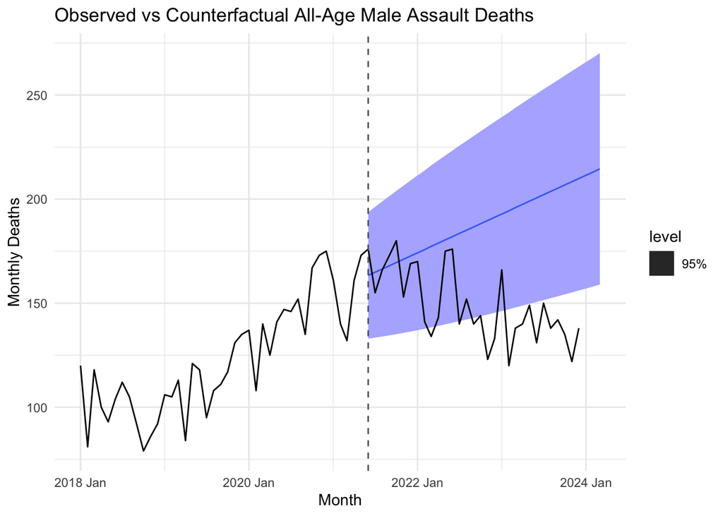

```r
monthly_m.ts <- prepare_ts("../CleanData/all_age_m_assault.csv")
monthly_m.ts <- create_intervention(monthly_m.ts, "2021-06-01")

m_arima <- fit_arima(monthly_m.ts)

fc_m <- counterfactual_forecast(monthly_m.ts, "2021-06-01", 34)

plot_counterfactual(
  fc_m,
  monthly_m.ts,
  "2021-06-01",
  "Observed vs Counterfactual All-Age Male Assault Deaths"
)
```

### 4.6.2 Female

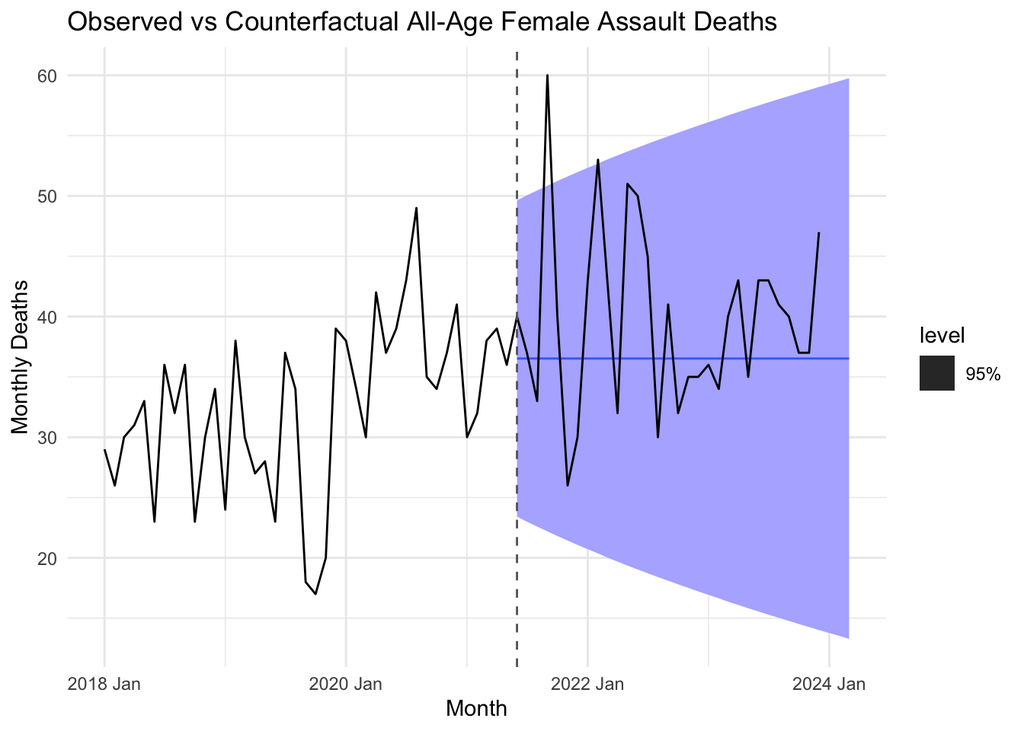

```r
monthly_f.ts <- prepare_ts("../CleanData/all_age_f_assault.csv")
monthly_f.ts <- create_intervention(monthly_f.ts, "2021-06-01")

f_arima <- fit_arima(monthly_f.ts)

fc_f <- counterfactual_forecast(monthly_f.ts, "2021-06-01", 34)

plot_counterfactual(
  fc_f,
  monthly_f.ts,
  "2021-06-01",
  "Observed vs Counterfactual All-Age Female Assault Deaths"
)
```

## 4.7 Model Diagnostics

**Residual Diagnostics**

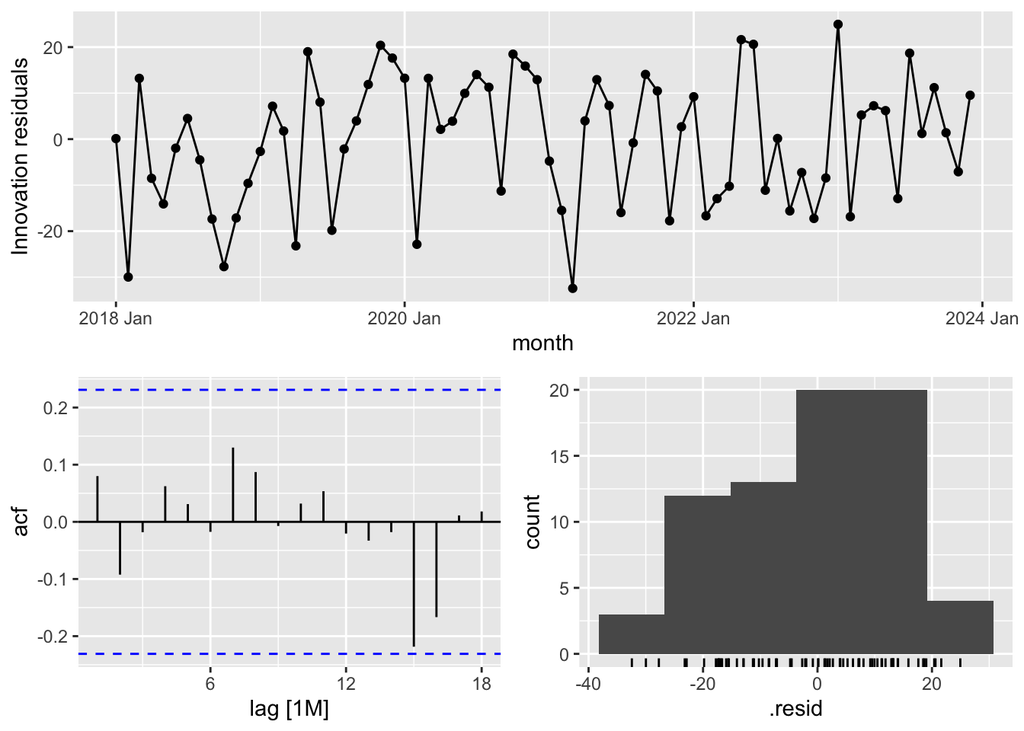

```r
m_arima %>% gg_tsresiduals()
```

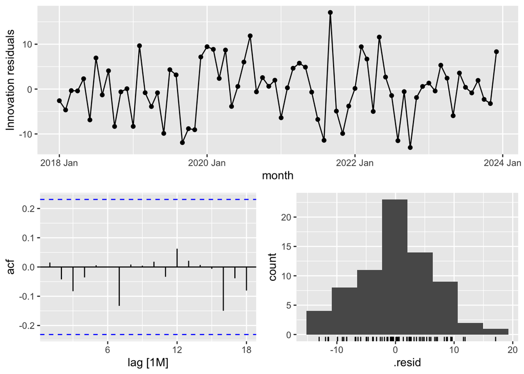

```r
f_arima %>% gg_tsresiduals()
```

**Ljung-Box Test**

```r
augment(m_arima) %>% features(.resid, ljung_box)
```

```
## # A tibble: 1 × 3
##   .model lb_stat lb_pvalue
##   <chr>    <dbl>     <dbl>
## 1 arima    0.481     0.488
```

```r
augment(f_arima) %>% features(.resid, ljung_box)
```

```
## # A tibble: 1 × 3
##   .model lb_stat lb_pvalue
##   <chr>    <dbl>     <dbl>
## 1 arima   0.0174     0.895
```

## 4.8 Sensitivity Analysis

**Pre-Intervention Model Selection - Female and Male**

```r
pre_data_f <- monthly_f.ts %>%
  filter(month_year < "2021-06-01")

pre_data_m <- monthly_m.ts %>%
  filter(month_year < "2021-06-01")

f_pre <- pre_data_f %>%
  model(arima = ARIMA(Deaths))

m_pre <- pre_data_m %>%
  model(arima = ARIMA(Deaths))

report(f_pre)
```

```
## Series: Deaths
## Model: ARIMA(0,1,1)
##
## Coefficients:
##           ma1
##       -0.7451
## s.e.   0.1295
##
## sigma^2 estimated as 44.71:  log likelihood=-132.66
## AIC=269.32   AICc=269.65   BIC=272.7
```

```r
report(m_pre)
```

```
## Series: Deaths
## Model: ARIMA(0,1,1) w/ drift
##
## Coefficients:
##           ma1  constant
##       -0.7330    1.5521
## s.e.   0.1261    0.6969
##
## sigma^2 estimated as 240:  log likelihood=-165.73
## AIC=337.45   AICc=338.12   BIC=342.52
```

**Fitting with Full Data**

```r
f_sensitivity <- monthly_f.ts %>%
  model(
    arima = ARIMA(
      Deaths ~ step + ramp + pdq(0,0,1),
      stepwise = FALSE
    )
  )

m_sensitivity <- monthly_m.ts %>%
  model(
    arima = ARIMA(
      Deaths ~ step + ramp + pdq(0,1,0) + PDQ(1,0,0),
      stepwise = FALSE
    )
  )

report(f_sensitivity)
```

```
## Series: Deaths
## Model: LM w/ ARIMA(0,0,1) errors
##
## Coefficients:
##          ma1    step     ramp  intercept
##       0.2864  7.3015  -0.0006    32.4957
## s.e.  0.1122  3.4146   0.1718     1.3601
##
## sigma^2 estimated as 49.14:  log likelihood=-240.36
## AIC=490.71   AICc=491.62   BIC=502.1
```

```r
report(m_sensitivity)
```

```
## Series: Deaths
## Model: LM w/ ARIMA(0,1,0)(1,0,0)[12] errors
##
## Coefficients:
##         sar1     step     ramp
##       0.3254   1.8364  -1.2607
## s.e.  0.1246  16.6397   3.8476
##
## sigma^2 estimated as 310.6:  log likelihood=-303.6
## AIC=615.2   AICc=615.8   BIC=624.25
```

**Forecasted Graphs**

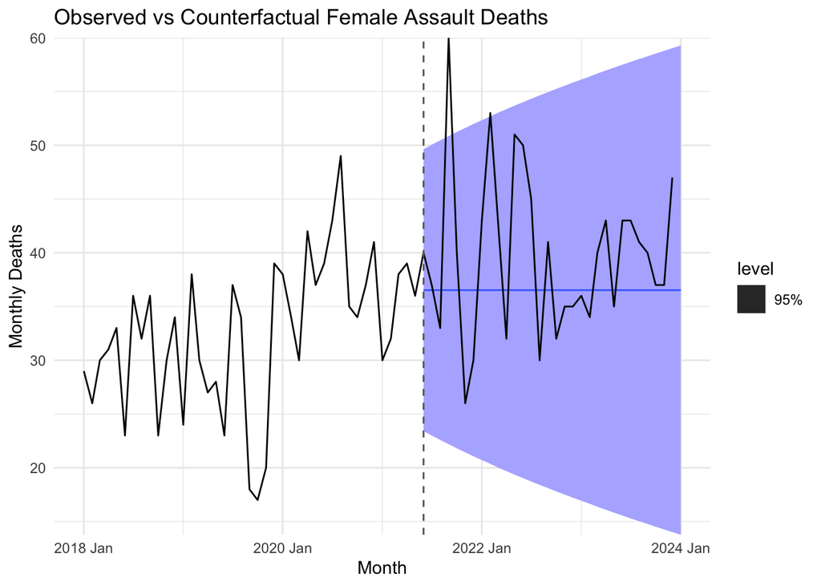

```r
fc_counterfactual_f <- f_pre %>%
  forecast(h = 28+4)

fc_counterfactual_m <- m_pre %>%
  forecast(h = 28+4)

autoplot(fc_counterfactual_f, monthly_f.ts, level = 95) +
  geom_vline(
    xintercept = as.numeric(as_date("2021-06-01")),
    linetype = "dashed",
    color = "grey40"
  ) +
  labs(
    title = "Observed vs Counterfactual Female Assault Deaths",
    y = "Monthly Deaths",
    x = "Month"
  ) +
  scale_y_continuous(expand = c(0,0)) +
  theme_minimal()
```

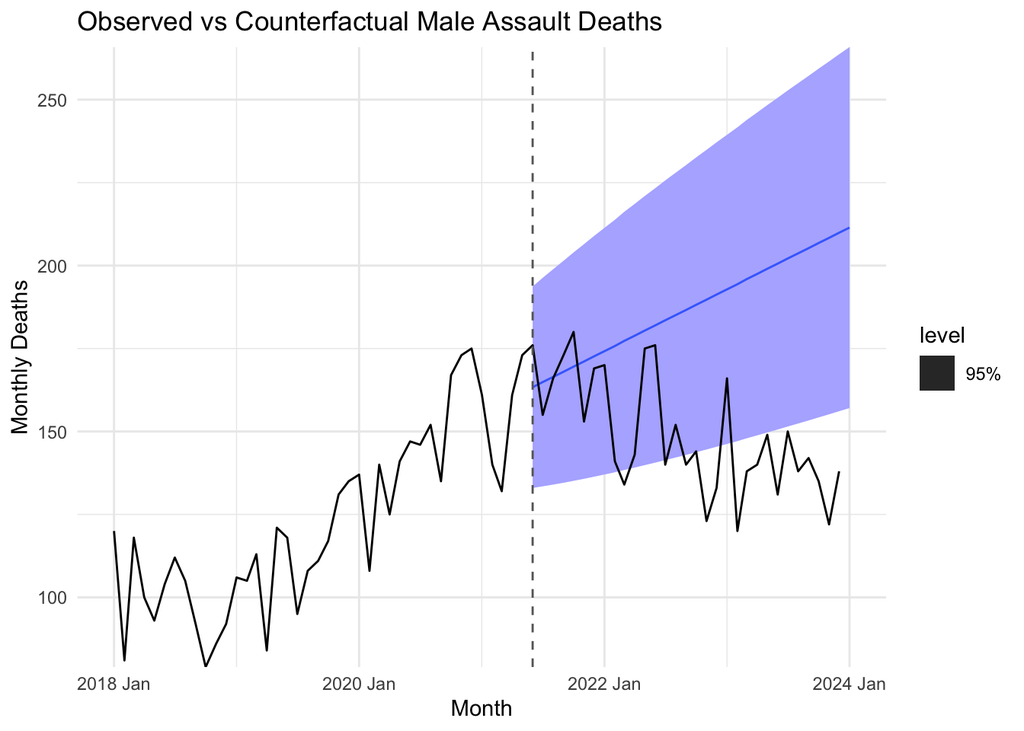

```r
autoplot(fc_counterfactual_m, monthly_m.ts, level = 95) +
  geom_vline(
    xintercept = as.numeric(as_date("2021-06-01")),
    linetype = "dashed",
    color = "grey40"
  ) +
  labs(
    title = "Observed vs Counterfactual Male Assault Deaths",
    y = "Monthly Deaths",
    x = "Month"
  ) +
  scale_y_continuous(expand = c(0,0)) +
  theme_minimal()
```